# Worldwide Governance Indicators

- Show All Code
- Hide All Code
- View Source

Published

October 19, 2022

[interactive chart not shown]

**Last Update:** October 11, 2025 - 08:36

This report presents the results of six broad dimensions of governance over 215 countries and territories between 1996-2021.

# Table of Contents

1. Introduction
2. Motivation
3. Dataset
4. Data Preparation
5. Visualizations
   - Correlation between Indicators
   - Most recent results 2021 by Country
   - Comparison by Continent
   - Comparison between the top 3 Countries of 2021
   - USA progression over time
6. Conclusion
7. References

# Introduction

Governance consists of the traditions and institutions by which authority in a country is exercised. This includes the process by which governments are selected, monitored, and replaced; the government’s capacity to effectively formulate and implement sound policies; and the respect of citizens and the state for the institutions that govern economic and social interactions among them.

This report is based on the data source [*Worldwide-Governance-Indicators*](https://datacatalog.worldbank.org/search/dataset/0038026/Worldwide-Governance-Indicators) (Sep 23, 2022), which highlights six broad indicators of a country’s governance. The data includes results from 1996 to 2021.

# Motivation

As a worldwide traveler who has just recently been in an almost 3-month study abroad program in Europe - traveling across 13 different countries, I have always been curious to understand the indicators that determine the success of a nation and how they are compared between one another. For that reason, when navigating through https://www.worldbank.org/ looking for some dataset to perform analyses, I found the one on which this report is based, so I decided to explore it.

# Dataset

The dataset lists composite governance indicators based on over 30 underlying data sources. As mentioned in the introduction, it reports on six broad dimensions of governance for over 215 countries and territories over the period 1996-2021, which are:

1. Control of Corruption;
2. Government Effectiveness;
3. Political Stability and Absence of Violence;
4. Regulatory Quality;
5. Rule of Law;
6. Voice and Accountability.

Feel free to download the raw data from the link below if you also want to explore it in-depth!

**[Download Raw Data]**

# Data Preparation

For ease of understanding and to make our analyses more transparent, during the data preparation stage, I filtered the indicators by their estimates which give each country a score on the aggregate hand, in units of standard normal distribution, ranging from approximately -2.5 to 2.5.

I have attached below the prepared data that I used throughout this report. You are welcome to explore the code, manipulate the data, or download it in the format you wish from the table below.

```r
# 1_Importing
  # url <- "https://databank.worldbank.org/data/download/WGI_csv.zip"
  # tf <- tempfile(tmpdir = directory, fileext = ".zip")
  # download.file(url, tf)
  # unzip(tf)
df_data <- read_csv("WGIData.csv")
df_country <- read_csv("WGICountry.csv")
df_continent <- countrycode::codelist %>% select(continent, wb, country.name.en, iso2c, unicode.symbol)

# 2_Cleaning
  df_data <- df_data %>%
                clean_names() %>%
                select(-c("indicator_code","x28")) %>%
                pivot_longer(-c("country_name", "country_code", "indicator_name"),
                             names_to = "year",
                             values_to = "value") %>%
                mutate(year = str_remove_all(year, pattern = "x")) %>%
                filter(str_detect(indicator_name, "Estimate")) %>%
                mutate(indicator_name = str_extract(indicator_name, pattern = "(.*):"),
                       indicator_name = str_remove_all(indicator_name, ":")) %>%
                mutate(year = as.integer(year),
                       value = as.double(value))

  df_country <- df_country %>%
                  clean_names() %>%
                  select(country_code, table_name, region)

  df_continent <- df_continent %>%
                    clean_names() %>%
                    rename(country_code = wb,
                           country_name = country_name_en)

# 3_Creating_Master_Table
  df <- df_data %>%
          inner_join(df_country %>% select(country_code, region),
                     by = "country_code") %>%
          inner_join(df_continent %>% select(country_code, continent, iso2c, unicode_symbol),
                     by = "country_code") %>%
          mutate_all(~str_trim(., side = "both")) %>%
          mutate(continent = case_when(region == "Latin America & Caribbean" ~ "South America",
                                       region == "North America" ~ "North America",
                                       country_name == "Greenland" ~ "North America",
                                             T ~ continent)) %>%
          mutate(continent = case_when(country_name == "Mexico" ~ "North America",
                                       T ~ continent)) %>%
          mutate(indicator_name = case_when(indicator_name == "Political Stability and Absence of Violence/Terrorism" ~ "Political Stability",
                               T ~ indicator_name)) %>%
          mutate(year = as.integer(year),
                 value = as.double(value),
                 value = round(value, 2)) %>%
          filter(continent != "") %>%
          filter(value != "") %>%
          select(-region) %>%
          arrange(year, country_name)

# DATA TABLE
  # Preparing
    dt <- df %>%
            select(country_name,  country_code, continent, indicator_name, year, value) %>%
            mutate_at(.vars = c("country_name", "country_code", "indicator_name", "year") ,~as_factor(.)) %>%
            arrange(continent) %>%
            mutate(continent = as_factor(continent)) %>%
            arrange(year, country_name) %>%

  # Creating
          DT::datatable(rownames = FALSE,
                        width = "100%",
                        filter = "top",
                        colnames = c('Country','Code', 'Continent', 'Indicator', "Year", "Score"),
                        class = 'cell-border stripe',
                        extensions = c("Responsive", "Buttons"),
                                      options = list(
                                                      autowidth = TRUE,
                                                      lengthMenu = c(6, 12, 25, 50),
                                                      dom = "Blfrtip",
                                                      buttons = c("copy", "csv", "excel", "print", "pdf"),
                                                      initComplete = JS("function(settings, json) {",
      "$(this.api().table().header()).css({'background-color': '#c23d1d', 'color': '#fff'});",
      "}")))

htmlwidgets::saveWidget(dt, file = "widgets/WGI_DT.html")
# write_csv(df, file = "./WGI_cleaned.csv")

print(df)
## # A tibble: 27,591 × 8
##    country_name country_code indicator_name           year value continent iso2c
##    <chr>        <chr>        <chr>                   <int> <dbl> <chr>     <chr>
##  1 Afghanistan  AFG          Control of Corruption    1996 -1.29 Asia      AF
##  2 Afghanistan  AFG          Government Effectivene…  1996 -2.18 Asia      AF
##  3 Afghanistan  AFG          Political Stability      1996 -2.42 Asia      AF
##  4 Afghanistan  AFG          Regulatory Quality       1996 -2.09 Asia      AF
##  5 Afghanistan  AFG          Rule of Law              1996 -1.79 Asia      AF
##  6 Afghanistan  AFG          Voice and Accountabili…  1996 -1.91 Asia      AF
##  7 Albania      ALB          Control of Corruption    1996 -0.89 Europe    AL
##  8 Albania      ALB          Government Effectivene…  1996 -0.69 Europe    AL
##  9 Albania      ALB          Political Stability      1996 -0.34 Europe    AL
## 10 Albania      ALB          Regulatory Quality       1996 -0.47 Europe    AL
## # ℹ 27,581 more rows
## # ℹ 1 more variable: unicode_symbol <chr>
```

[interactive chart not shown]

# Visualizations

As this is a significant project involving many variables and records, I created five charts to understand the results better.

1. Correlation between Indicators **(Correlation Matrix)**
2. Most recent results 2021 by Country **(Interactive Map)**
3. Comparison by Continent **(Box Plot)**
4. Comparison between the top 3 Countries of 2021 **(Line Chart)**
5. USA progression over time **(Animated Line Chart)**

Most of the charts are interactive! If you see a *[Full Screen]* option next to a chart, it means the chart is interactive and you can view it in full screen.

### Correlation between Indicators

The correlation chart below shows the connection between indicators.

For purposes of text space in the chart below, I have shortened the indicator’s names:

- **Corruption** = Control of Corruption;
- **Effectiveness** = Government Effectiveness;
- **Stability** = Political Stability and Absence of Violence;
- **Regulations** = Regulatory Quality;
- **Law** = Rule of Law;
- **Voice** = Voice and Accountability.

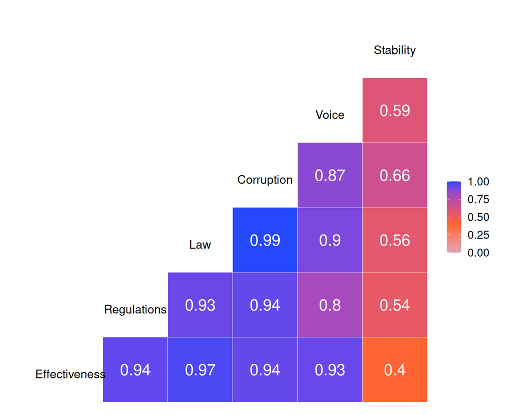

Correlation between Indicators.

```r
# Correlation Matrix
df_cor <- df %>%
            select(country_name:continent) %>%
            pivot_wider(names_from = "indicator_name",
                        values_from = "value") %>%
            select(5:10) %>%
            rename(Corruption = 1,
                   Effectiveness = 2,
                   Stability = 3,
                   Regulations = 4,
                   Law = 5,
                   Voice = 6) %>%
            corrr::correlate(quiet = TRUE) %>%
            corrr::rearrange()

# Correlation Plot
cor_plot <- df_cor %>%
              GGally::ggcorr(low = "#abc3ff",
                             mid = "#ff6432",
                             high = "#0048ff",
                             label = TRUE,
                             label_round = 2,
                             label_color = "white",
                             label_size = 6,
                             legend.size = 12,
                             digits = 2,
                             limits = c(0, 1),
                             midpoint = 0.4,
                             palette = NULL,
                             geom = "tile",
                             hjust = 0.5,
                             vjust = 1,
                             size = 4.5,
                             angle = 0) +
              # ggtitle("Indicators Correlation") +
              cowplot::theme_cowplot() +
              theme(plot.title = element_text(size = 22, hjust = .5))

print(df_cor)
## # A tibble: 6 × 7
##   term          Effectiveness Regulations    Law Corruption  Voice Stability
##   <chr>                 <dbl>       <dbl>  <dbl>      <dbl>  <dbl>     <dbl>
## 1 Effectiveness        NA           0.932  0.929      0.918  0.752     0.714
## 2 Regulations           0.932      NA      0.903      0.865  0.781     0.667
## 3 Law                   0.929       0.903 NA          0.937  0.822     0.789
## 4 Corruption            0.918       0.865  0.937     NA      0.772     0.750
## 5 Voice                 0.752       0.781  0.822      0.772 NA         0.688
## 6 Stability             0.714       0.667  0.789      0.750  0.688    NA
print(cor_plot)
```

### Most recent results 2021 by Country

The map below shows the **2021 results** for each country.

As this is an interactive map, for you to see the scores, you will need to hover the mouse over the country, and then you will see the results of all six indicators, including the mean.

```r
df_2021 <- df %>%
            mutate(value = round(value, 2)) %>%
            filter(year == "2021") %>%
            select(country_name, country_code, indicator_name, value) %>%
            pivot_wider(names_from = "indicator_name",
                        values_from = "value") %>%
            clean_names() %>%
            rowwise() %>%
            mutate(mean = mean(c_across(3:8)),
                   mean = round(mean, 2))

# Highcharter
map_df_2021 <- hcmap(map = "custom/world-robinson-lowres",
                     download_map_data = FALSE,
                     data = df_2021,
                     value = "mean",
                     borderColor = "black",
                     borderWidth = .7,
                     nullColor = "#d3d3d3",
                     joinBy = c("iso-a3", "country_code")) %>%

                hc_colorAxis(stops = color_stops(colors = viridisLite::mako(10, begin = 0.01))) %>%

                hc_title(text = "<b>WGI Results 2021</b><i>(by Country)</i>",
                         margin = 5,
                         floating= FALSE,
                         align = "center",
                         style = list(fontSize = "28px",
                                      color = "#252223",
                                      useHTML = TRUE)) %>%

                # hc_subtitle(text = "<i>2021</i>",
                #             margin = 20,
                #             floating= FALSE,
                #             align = "center",
                #             style = list(fontSize = "28px",
                #                          color = "#e1a615",
                #                          useHTML = TRUE)) %>%

                hc_mapNavigation(enabled = TRUE,
                                 enableMouseWheelZoom = TRUE,
                                 enableDoubleClickZoom = TRUE) %>%

                hc_exporting(enabled = TRUE,
                             filename = "WGI_2021_Map") %>%

                hc_credits(enabled = FALSE) %>%

                hc_tooltip(shared = TRUE,
                            useHTML = TRUE,
                            headerFormat = '<table><tr><th, colspan="2">{point.key}</th></tr>',
                            pointFormat = '<tr><td style="color: {#252223}"><b>{point.country_name}</b><br>Control of Corruption: {point.control_of_corruption}<br>Government Effectiveness: {point.government_effectiveness}<br>Political Stability: {point.political_stability}<br>Regulatory Quality: {point.regulatory_quality}<br>Rule of Law: {point.rule_of_law}<br>Voice and Accountability: {point.voice_and_accountability}<br><b>Mean: {point.value}</b>')

htmlwidgets::saveWidget(map_df_2021, "widgets/WGI_2021.html")

print(df_2021)
## # A tibble: 205 × 9
## # Rowwise:
##    country_name        country_code control_of_corruption government_effective…¹
##    <chr>               <chr>                        <dbl>                  <dbl>
##  1 Afghanistan         AFG                          -1.14                  -1.63
##  2 Albania             ALB                          -0.56                   0
##  3 Algeria             DZA                          -0.61                  -0.62
##  4 American Samoa      ASM                           1.33                   0.7
##  5 Andorra             AND                           1.33                   1.82
##  6 Angola              AGO                          -0.66                  -1.06
##  7 Antigua and Barbuda ATG                           0.26                  -0.14
##  8 Argentina           ARG                          -0.4                   -0.36
##  9 Armenia             ARM                           0.07                  -0.25
## 10 Aruba               ABW                           0.83                   1.13
## # ℹ 195 more rows
## # ℹ abbreviated name: ¹government_effectiveness
## # ℹ 5 more variables: political_stability <dbl>, regulatory_quality <dbl>,
## #   rule_of_law <dbl>, voice_and_accountability <dbl>, mean <dbl>
```

[interactive chart not shown]

### Comparison by Continent

The box plot below is based on the **2021 results** and demonstrates how a continent is compared to each other within each indicator.

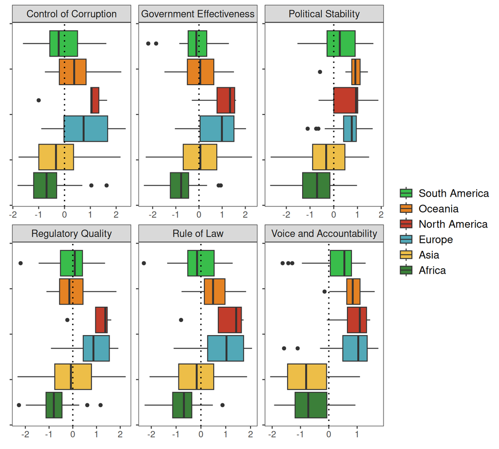

Comparison by Continent.

```r
cont_df_2021_plot <- df %>%
                      filter(year == 2021) %>%
                      ggplot(aes(x = year, y = value, fill = continent)) +
                      geom_boxplot(na.rm = T) +
                      scale_fill_manual(values = c("#3b7f39", "#edbe48", "#52a8b7", "#c23c2b", "#e48223", "#39bd4b")) +
                      coord_flip() +
                      facet_wrap(~indicator_name, scales = "free") +
                      # geom_hline(yintercept =-2, linetype = "dotted", size = .7, color = "black") +
                      # geom_hline(yintercept = -1, linetype = "dotted", size = .7, color = "black") +
                      geom_hline(yintercept = 0, linetype = "dotted", size = .7, color = "black") +
                      # geom_hline(yintercept = 1, linetype = "dotted", size = .7, color = "black") +
                      # geom_hline(yintercept = 2, linetype = "dotted", size = .7, color = "black") +
                      labs(x = element_blank(),
                           y = element_blank(),
                           fill = "") +
                      theme_bw() +
                      theme(axis.text.y = element_blank(),
                            axis.text.x = element_text(size = 10),
                            legend.text = element_text(size = 12),
                            panel.grid = element_blank(),
                            # strip.background = element_rect(fill = "#6e2b0e"),
                            strip.text = element_text(size = 11)) +
                      guides(fill = guide_legend(reverse = TRUE))
print(cont_df_2021_plot)
```

### Comparison between the top 3 Countries of 2021

The line chart below represents a progression of the top 3 countries of 2021 since 1996. By the way, the calculation of the top 3 countries was based on the average(mean) of the six indicators combined.

```r
top_3_2021 <- df %>%
                mutate(value = round(value, 2)) %>%
                select(country_name, country_code, indicator_name, year, value) %>%
                pivot_wider(names_from = "indicator_name",
                            values_from = "value") %>%
                clean_names() %>%
                rowwise() %>%
                mutate(mean = mean(c_across(4:9)),
                       mean = round(mean, 2)) %>%
                group_by(year) %>%
                arrange(year, desc(mean)) %>%
                mutate(rank = row_number()) %>%
                ungroup() %>%
                filter(year == 2021,
                       rank <= 3)

top_3_plot <- df %>%
                filter(country_name %in% c(top_3_2021$country_name)) %>%
                select(Country = country_name,
                       Code = country_code,
                       Continent = continent,
                       Indicator = indicator_name,
                       Year = year,
                       Score = value) %>%
                mutate(Indicator = case_when(Indicator == "Government Effectiveness" ~ "Effectiveness",
                                             T ~ Indicator)) %>%
                ggplot(aes(x = Year, y = Score, color = Country)) +
                geom_line(size = .7) +
                geom_point(color = "black", size = .5) +
                facet_wrap(~Indicator, scales = "free") +
                scale_x_continuous(breaks = seq(1995, 2020, 10)) +
                scale_colour_brewer(palette = "Dark2") +
                labs(title = "",
                     color = "",
                     y = element_blank(),
                     x = element_blank()) +
                theme_bw() +
                theme(legend.text = element_text(size = 10),
                      # strip.background = element_rect(fill = "#bcdefc"),
                      strip.text = element_text(size = 10, color = "black"))

top_3_plotly <- ggplotly(top_3_plot, tooltip = c("Year", "Score")) %>%
                          config(displaylogo = FALSE,
                                 modeBarButtonsToRemove = c("zoom2d","zoomIn2d", "zoomOut2d",
                                                            "select",
                                                            "lasso2d",
                                                            "pan2d"),
                                 toImageButtonOptions = list(format = "svg",
                                                             filename = "North_America_Results"))

htmlwidgets::saveWidget(top_3_plotly, file = "widgets/Top_3_Comparison.html")

print(top_3_2021)
## # A tibble: 3 × 11
##   country_name country_code  year control_of_corruption government_effectiveness
##   <chr>        <chr>        <int>                 <dbl>                    <dbl>
## 1 Finland      FIN           2021                  2.27                     1.96
## 2 Denmark      DNK           2021                  2.37                     2
## 3 Norway       NOR           2021                  2.14                     1.84
## # ℹ 6 more variables: political_stability <dbl>, regulatory_quality <dbl>,
## #   rule_of_law <dbl>, voice_and_accountability <dbl>, mean <dbl>, rank <int>
```

[interactive chart not shown]

### USA progression over time

```r
df_usa <- df %>%
            filter(country_code == "USA") %>%
            select(country_name:value) %>%
            rename(Year = year,
                   Score = value)

usa_plot <- df_usa %>%
              ggplot(aes(Year, Score)) +
              geom_point(aes(frame = Year, color = indicator_name)) +
              geom_line(aes(color = indicator_name), size = 1, alpha = 0.8) +
              theme_bw() +
              labs(color = " ") +
              # ggtitle("USA Governance Indicators") +
              scale_color_viridis_d(option = "turbo") +
              # gganimate::transition_reveal(Year) +
              # coord_cartesian(clip = 'off') +
              theme(axis.title = element_blank(),
                    legend.text = element_text(size = 12),
                    plot.title = element_text(size = 18, hjust = .5),
                    axis.text = element_text(size = 12))

# usa_animation <- animate(usa_plot, fps = 10, width = 600, height = 400)
# anim_save("usa_animation.gif", usa_animation)

usa_plotly <- ggplotly(usa_plot, tooltip = c("Year", "Score")) %>%
                animation_opts(1000, ) %>%
                animation_button(label = "Animate") %>%
                config(displaylogo = FALSE,
                                 modeBarButtonsToRemove = c("zoom2d","zoomIn2d", "zoomOut2d",
                                                            "select",
                                                            "lasso2d",
                                                            "pan2d",
                                                            "autoScale"),
                                 toImageButtonOptions = list(format = "svg",
                                                             filename = "North_America_Results"))

htmlwidgets::saveWidget(usa_plotly, "widgets/USA_Plotly.html")
print(df_usa)
## # A tibble: 138 × 5
##    country_name  country_code indicator_name            Year Score
##    <chr>         <chr>        <chr>                    <int> <dbl>
##  1 United States USA          Control of Corruption     1996  1.57
##  2 United States USA          Government Effectiveness  1996  1.52
##  3 United States USA          Political Stability       1996  0.94
##  4 United States USA          Regulatory Quality        1996  1.59
##  5 United States USA          Rule of Law               1996  1.5
##  6 United States USA          Voice and Accountability  1996  1.35
##  7 United States USA          Control of Corruption     1998  1.55
##  8 United States USA          Government Effectiveness  1998  1.7
##  9 United States USA          Political Stability       1998  0.88
## 10 United States USA          Regulatory Quality        1998  1.61
## # ℹ 128 more rows
```

[interactive chart not shown]

# Conclusion

In conclusion, this was a very satisfying and exciting project, and I learned much from it. It highlighted the six governance indicators which determine how prosperous a country is compared to another and how they have progressed over time.

As this is an open-source project, you are welcome to edit this content and send me a pull request through the GitHub edit button I embedded in the footer of this page. Also, in the comment section, let me know your thoughts on this project and which comparisons and charts you wish you saw. I will be reiterating it and adding more content throughout the time and, of course, always keep it updated with the most recent data.

Thank you!

## References

Arel-Bundock, Vincent. 2024. *Countrycode: Convert Country Names and Country Codes*. https://vincentarelbundock.github.io/countrycode/.

Arel-Bundock, Vincent, Nils Enevoldsen, and CJ Yetman. 2018. “Countrycode: An r Package to Convert Country Names and Country Codes.” *Journal of Open Source Software* 3 (28): 848. https://doi.org/10.21105/joss.00848.

Bryan, Jennifer. 2023. *Gapminder: Data from Gapminder*. https://github.com/jennybc/gapminder.

Firke, Sam. 2024. *Janitor: Simple Tools for Examining and Cleaning Dirty Data*. https://github.com/sfirke/janitor.

Kuhn, Max, Simon Jackson, and Jorge Cimentada. 2022. *Corrr: Correlations in r*. https://github.com/tidymodels/corrr.

Kunst, Joshua. 2022. *Highcharter: A Wrapper for the Highcharts Library*. https://jkunst.com/highcharter/.

Müller, Kirill. 2020. *Here: A Simpler Way to Find Your Files*. https://here.r-lib.org/.

Pedersen, Thomas Lin, and David Robinson. 2024. *Gganimate: A Grammar of Animated Graphics*. https://gganimate.com.

R Core Team. 2024. *R: A Language and Environment for Statistical Computing*. Vienna, Austria: R Foundation for Statistical Computing. https://www.R-project.org/.

Rinker, Tyler W., and Dason Kurkiewicz. 2018. *pacman: Package Management for R*. Buffalo, New York. http://github.com/trinker/pacman.

Rinker, Tyler, and Dason Kurkiewicz. 2019. *Pacman: Package Management Tool*. https://github.com/trinker/pacman.

Schloerke, Barret, Di Cook, Joseph Larmarange, Francois Briatte, Moritz Marbach, Edwin Thoen, Amos Elberg, and Jason Crowley. 2024. *GGally: Extension to Ggplot2*. https://ggobi.github.io/ggally/.

Sievert, Carson. 2020. *Interactive Web-Based Data Visualization with r, Plotly, and Shiny*. Chapman; Hall/CRC. https://plotly-r.com.

Sievert, Carson, Chris Parmer, Toby Hocking, Scott Chamberlain, Karthik Ram, Marianne Corvellec, and Pedro Despouy. 2024. *Plotly: Create Interactive Web Graphics via Plotly.js*. https://plotly-r.com.

Vaidyanathan, Ramnath, Yihui Xie, JJ Allaire, Joe Cheng, Carson Sievert, and Kenton Russell. 2023. *Htmlwidgets: HTML Widgets for r*. https://github.com/ramnathv/htmlwidgets.

Wickham, Hadley. 2016. *Ggplot2: Elegant Graphics for Data Analysis*. Springer-Verlag New York. https://ggplot2.tidyverse.org.

———. 2023a. *Forcats: Tools for Working with Categorical Variables (Factors)*. https://forcats.tidyverse.org/.

———. 2023b. *Httr: Tools for Working with URLs and HTTP*. https://httr.r-lib.org/.

———. 2023c. *Stringr: Simple, Consistent Wrappers for Common String Operations*. https://stringr.tidyverse.org.

Wickham, Hadley, Winston Chang, Lionel Henry, Thomas Lin Pedersen, Kohske Takahashi, Claus Wilke, Kara Woo, Hiroaki Yutani, Dewey Dunnington, and Teun van den Brand. 2024. *Ggplot2: Create Elegant Data Visualisations Using the Grammar of Graphics*. https://ggplot2.tidyverse.org.

Wickham, Hadley, Romain François, Lionel Henry, Kirill Müller, and Davis Vaughan. 2023. *Dplyr: A Grammar of Data Manipulation*. https://dplyr.tidyverse.org.

Wickham, Hadley, Jim Hester, and Jennifer Bryan. 2024. *Readr: Read Rectangular Text Data*. https://readr.tidyverse.org.

Wickham, Hadley, Davis Vaughan, and Maximilian Girlich. 2024. *Tidyr: Tidy Messy Data*. https://tidyr.tidyverse.org.

Wilke, Claus O. 2024. *Cowplot: Streamlined Plot Theme and Plot Annotations for Ggplot2*. https://wilkelab.org/cowplot/.

World Bank Group. Sep 23, 2022. *Worldwide Governance Indicators*. World Bank Group. https://datacatalog.worldbank.org/search/dataset/0038026/Worldwide-Governance-Indicators.

Wright, Kevin. 2021. *Corrgram: Plot a Correlogram*. https://kwstat.github.io/corrgram/.

Xie, Yihui. 2014. “Knitr: A Comprehensive Tool for Reproducible Research in R.” In *Implementing Reproducible Computational Research*, edited by Victoria Stodden, Friedrich Leisch, and Roger D. Peng. Chapman; Hall/CRC.

———. 2015. *Dynamic Documents with R and Knitr*. 2nd ed. Boca Raton, Florida: Chapman; Hall/CRC. https://yihui.org/knitr/.

———. 2024. *Knitr: A General-Purpose Package for Dynamic Report Generation in r*. https://yihui.org/knitr/.

Xie, Yihui, Joe Cheng, and Xianying Tan. 2024. *DT: A Wrapper of the JavaScript Library DataTables*. https://github.com/rstudio/DT.